# STA-6543_Final_Project

William Hyltin ror910, Tim Harrison, Holly Milazzo

2024-08-03

## Data Cleaning and Observations

```r
head(trainRaw)
```

```
## # A tibble: 6 × 81
##      Id MSSubClass MSZoning LotFrontage LotArea Street Alley LotShape
##   <dbl>      <dbl> <chr>          <dbl>   <dbl> <chr>  <chr> <chr>
## 1     1         60 RL                65    8450 Pave   <NA>  Reg
## 2     2         20 RL                80    9600 Pave   <NA>  Reg
## 3     3         60 RL                68   11250 Pave   <NA>  IR1
## 4     4         70 RL                60    9550 Pave   <NA>  IR1
## 5     5         60 RL                84   14260 Pave   <NA>  IR1
## 6     6         50 RL                85   14115 Pave   <NA>  IR1
## # ℹ 73 more variables: LandContour <chr>, Utilities <chr>, LotConfig <chr>,
## #   LandSlope <chr>, Neighborhood <chr>, Condition1 <chr>, Condition2 <chr>,
## #   BldgType <chr>, HouseStyle <chr>, OverallQual <dbl>, OverallCond <dbl>,
## #   YearBuilt <dbl>, YearRemodAdd <dbl>, RoofStyle <chr>, RoofMatl <chr>,
## #   Exterior1st <chr>, Exterior2nd <chr>, MasVnrType <chr>, MasVnrArea <dbl>,
## #   ExterQual <chr>, ExterCond <chr>, Foundation <chr>, BsmtQual <chr>,
## #   BsmtCond <chr>, BsmtExposure <chr>, BsmtFinType1 <chr>, BsmtFinSF1 <dbl>, …
```

```r
skim(trainRaw)
```

Data summary

| Name | trainRaw |
| --- | --- |
| Number of rows | 1460 |
| Number of columns | 81 |
| _______________________ |  |
| Column type frequency: |  |
| character | 43 |
| numeric | 38 |
| ________________________ |  |
| Group variables | None |

**Variable type: character**

| skim_variable | n_missing | complete_rate | min | max | empty | n_unique | whitespace |
| --- | --- | --- | --- | --- | --- | --- | --- |
| MSZoning | 0 | 1.00 | 2 | 7 | 0 | 5 | 0 |
| Street | 0 | 1.00 | 4 | 4 | 0 | 2 | 0 |
| Alley | 1369 | 0.06 | 4 | 4 | 0 | 2 | 0 |
| LotShape | 0 | 1.00 | 3 | 3 | 0 | 4 | 0 |
| LandContour | 0 | 1.00 | 3 | 3 | 0 | 4 | 0 |
| Utilities | 0 | 1.00 | 6 | 6 | 0 | 2 | 0 |
| LotConfig | 0 | 1.00 | 3 | 7 | 0 | 5 | 0 |
| LandSlope | 0 | 1.00 | 3 | 3 | 0 | 3 | 0 |
| Neighborhood | 0 | 1.00 | 5 | 7 | 0 | 25 | 0 |
| Condition1 | 0 | 1.00 | 4 | 6 | 0 | 9 | 0 |
| Condition2 | 0 | 1.00 | 4 | 6 | 0 | 8 | 0 |
| BldgType | 0 | 1.00 | 4 | 6 | 0 | 5 | 0 |
| HouseStyle | 0 | 1.00 | 4 | 6 | 0 | 8 | 0 |
| RoofStyle | 0 | 1.00 | 3 | 7 | 0 | 6 | 0 |
| RoofMatl | 0 | 1.00 | 4 | 7 | 0 | 8 | 0 |
| Exterior1st | 0 | 1.00 | 5 | 7 | 0 | 15 | 0 |
| Exterior2nd | 0 | 1.00 | 5 | 7 | 0 | 16 | 0 |
| MasVnrType | 8 | 0.99 | 4 | 7 | 0 | 4 | 0 |
| ExterQual | 0 | 1.00 | 2 | 2 | 0 | 4 | 0 |
| ExterCond | 0 | 1.00 | 2 | 2 | 0 | 5 | 0 |
| Foundation | 0 | 1.00 | 4 | 6 | 0 | 6 | 0 |
| BsmtQual | 37 | 0.97 | 2 | 2 | 0 | 4 | 0 |
| BsmtCond | 37 | 0.97 | 2 | 2 | 0 | 4 | 0 |
| BsmtExposure | 38 | 0.97 | 2 | 2 | 0 | 4 | 0 |
| BsmtFinType1 | 37 | 0.97 | 3 | 3 | 0 | 6 | 0 |
| BsmtFinType2 | 38 | 0.97 | 3 | 3 | 0 | 6 | 0 |
| Heating | 0 | 1.00 | 4 | 5 | 0 | 6 | 0 |
| HeatingQC | 0 | 1.00 | 2 | 2 | 0 | 5 | 0 |
| CentralAir | 0 | 1.00 | 1 | 1 | 0 | 2 | 0 |
| Electrical | 1 | 1.00 | 3 | 5 | 0 | 5 | 0 |
| KitchenQual | 0 | 1.00 | 2 | 2 | 0 | 4 | 0 |
| Functional | 0 | 1.00 | 3 | 4 | 0 | 7 | 0 |
| FireplaceQu | 690 | 0.53 | 2 | 2 | 0 | 5 | 0 |
| GarageType | 81 | 0.94 | 6 | 7 | 0 | 6 | 0 |
| GarageFinish | 81 | 0.94 | 3 | 3 | 0 | 3 | 0 |
| GarageQual | 81 | 0.94 | 2 | 2 | 0 | 5 | 0 |
| GarageCond | 81 | 0.94 | 2 | 2 | 0 | 5 | 0 |
| PavedDrive | 0 | 1.00 | 1 | 1 | 0 | 3 | 0 |
| PoolQC | 1453 | 0.00 | 2 | 2 | 0 | 3 | 0 |
| Fence | 1179 | 0.19 | 4 | 5 | 0 | 4 | 0 |
| MiscFeature | 1406 | 0.04 | 4 | 4 | 0 | 4 | 0 |
| SaleType | 0 | 1.00 | 2 | 5 | 0 | 9 | 0 |
| SaleCondition | 0 | 1.00 | 6 | 7 | 0 | 6 | 0 |

**Variable type: numeric**

| skim_variable | n_missing | complete_rate | mean | sd | p0 | p25 | p50 | p75 | p100 | hist |
| --- | --- | --- | --- | --- | --- | --- | --- | --- | --- | --- |
| Id | 0 | 1.00 | 730.50 | 421.61 | 1 | 365.75 | 730.5 | 1095.25 | 1460 | ▇▇▇▇▇ |
| MSSubClass | 0 | 1.00 | 56.90 | 42.30 | 20 | 20.00 | 50.0 | 70.00 | 190 | ▇▅▂▁▁ |
| LotFrontage | 259 | 0.82 | 70.05 | 24.28 | 21 | 59.00 | 69.0 | 80.00 | 313 | ▇▃▁▁▁ |
| LotArea | 0 | 1.00 | 10516.83 | 9981.26 | 1300 | 7553.50 | 9478.5 | 11601.50 | 215245 | ▇▁▁▁▁ |
| OverallQual | 0 | 1.00 | 6.10 | 1.38 | 1 | 5.00 | 6.0 | 7.00 | 10 | ▁▂▇▅▁ |
| OverallCond | 0 | 1.00 | 5.58 | 1.11 | 1 | 5.00 | 5.0 | 6.00 | 9 | ▁▁▇▅▁ |
| YearBuilt | 0 | 1.00 | 1971.27 | 30.20 | 1872 | 1954.00 | 1973.0 | 2000.00 | 2010 | ▁▂▃▆▇ |
| YearRemodAdd | 0 | 1.00 | 1984.87 | 20.65 | 1950 | 1967.00 | 1994.0 | 2004.00 | 2010 | ▅▂▂▃▇ |
| MasVnrArea | 8 | 0.99 | 103.69 | 181.07 | 0 | 0.00 | 0.0 | 166.00 | 1600 | ▇▁▁▁▁ |
| BsmtFinSF1 | 0 | 1.00 | 443.64 | 456.10 | 0 | 0.00 | 383.5 | 712.25 | 5644 | ▇▁▁▁▁ |
| BsmtFinSF2 | 0 | 1.00 | 46.55 | 161.32 | 0 | 0.00 | 0.0 | 0.00 | 1474 | ▇▁▁▁▁ |
| BsmtUnfSF | 0 | 1.00 | 567.24 | 441.87 | 0 | 223.00 | 477.5 | 808.00 | 2336 | ▇▅▂▁▁ |
| TotalBsmtSF | 0 | 1.00 | 1057.43 | 438.71 | 0 | 795.75 | 991.5 | 1298.25 | 6110 | ▇▃▁▁▁ |
| 1stFlrSF | 0 | 1.00 | 1162.63 | 386.59 | 334 | 882.00 | 1087.0 | 1391.25 | 4692 | ▇▅▁▁▁ |
| 2ndFlrSF | 0 | 1.00 | 346.99 | 436.53 | 0 | 0.00 | 0.0 | 728.00 | 2065 | ▇▃▂▁▁ |
| LowQualFinSF | 0 | 1.00 | 5.84 | 48.62 | 0 | 0.00 | 0.0 | 0.00 | 572 | ▇▁▁▁▁ |
| GrLivArea | 0 | 1.00 | 1515.46 | 525.48 | 334 | 1129.50 | 1464.0 | 1776.75 | 5642 | ▇▇▁▁▁ |
| BsmtFullBath | 0 | 1.00 | 0.43 | 0.52 | 0 | 0.00 | 0.0 | 1.00 | 3 | ▇▆▁▁▁ |
| BsmtHalfBath | 0 | 1.00 | 0.06 | 0.24 | 0 | 0.00 | 0.0 | 0.00 | 2 | ▇▁▁▁▁ |
| FullBath | 0 | 1.00 | 1.57 | 0.55 | 0 | 1.00 | 2.0 | 2.00 | 3 | ▁▇▁▇▁ |
| HalfBath | 0 | 1.00 | 0.38 | 0.50 | 0 | 0.00 | 0.0 | 1.00 | 2 | ▇▁▅▁▁ |
| BedroomAbvGr | 0 | 1.00 | 2.87 | 0.82 | 0 | 2.00 | 3.0 | 3.00 | 8 | ▁▇▂▁▁ |
| KitchenAbvGr | 0 | 1.00 | 1.05 | 0.22 | 0 | 1.00 | 1.0 | 1.00 | 3 | ▁▇▁▁▁ |
| TotRmsAbvGrd | 0 | 1.00 | 6.52 | 1.63 | 2 | 5.00 | 6.0 | 7.00 | 14 | ▂▇▇▁▁ |
| Fireplaces | 0 | 1.00 | 0.61 | 0.64 | 0 | 0.00 | 1.0 | 1.00 | 3 | ▇▇▁▁▁ |
| GarageYrBlt | 81 | 0.94 | 1978.51 | 24.69 | 1900 | 1961.00 | 1980.0 | 2002.00 | 2010 | ▁▁▅▅▇ |
| GarageCars | 0 | 1.00 | 1.77 | 0.75 | 0 | 1.00 | 2.0 | 2.00 | 4 | ▁▃▇▂▁ |
| GarageArea | 0 | 1.00 | 472.98 | 213.80 | 0 | 334.50 | 480.0 | 576.00 | 1418 | ▂▇▃▁▁ |
| WoodDeckSF | 0 | 1.00 | 94.24 | 125.34 | 0 | 0.00 | 0.0 | 168.00 | 857 | ▇▂▁▁▁ |
| OpenPorchSF | 0 | 1.00 | 46.66 | 66.26 | 0 | 0.00 | 25.0 | 68.00 | 547 | ▇▁▁▁▁ |
| EnclosedPorch | 0 | 1.00 | 21.95 | 61.12 | 0 | 0.00 | 0.0 | 0.00 | 552 | ▇▁▁▁▁ |
| 3SsnPorch | 0 | 1.00 | 3.41 | 29.32 | 0 | 0.00 | 0.0 | 0.00 | 508 | ▇▁▁▁▁ |
| ScreenPorch | 0 | 1.00 | 15.06 | 55.76 | 0 | 0.00 | 0.0 | 0.00 | 480 | ▇▁▁▁▁ |
| PoolArea | 0 | 1.00 | 2.76 | 40.18 | 0 | 0.00 | 0.0 | 0.00 | 738 | ▇▁▁▁▁ |
| MiscVal | 0 | 1.00 | 43.49 | 496.12 | 0 | 0.00 | 0.0 | 0.00 | 15500 | ▇▁▁▁▁ |
| MoSold | 0 | 1.00 | 6.32 | 2.70 | 1 | 5.00 | 6.0 | 8.00 | 12 | ▃▆▇▃▃ |
| YrSold | 0 | 1.00 | 2007.82 | 1.33 | 2006 | 2007.00 | 2008.0 | 2009.00 | 2010 | ▇▇▇▇▅ |
| SalePrice | 0 | 1.00 | 180921.20 | 79442.50 | 34900 | 129975.00 | 163000.0 | 214000.00 | 755000 | ▇▅▁▁▁ |

Missing values in `LotFrontage`, `MasVnrArea`, `GarageYrBlt`, `Alley`, `MasVnrType`, `BsmtQual`, `BsmtCond`, `BsmtExposure`, `BsmtFinType1`, `BsmtFinType2`, `Electrical`, `FireplaceQu`, `GarageType`, `GarageFinish`, `GarageQual`, `GarageCond`, `PoolQC`, `Fence`, and `MiscFeature`. Some of these missing values may actually be informative, for example several missing values have to do with a basement, so a missing value there may just mean there is no basement in that home. As such we may be able to use logic to impute rather than statistical methods.  
`MSSubClass` also comes in as a numeric variable but appears to be a code for a categorical/factor variable. Some other variables are numeric for 1-10 scores, meaning they may be better suited as ordinal categorical variables, but considering the number of other ordinal categorical variable we may only need to address this if it causes any issues.  
Note that our test data set does not have the actual sale price of the houses, so post-resample methods will be unavailable.

```r
# Addressing MSSubClass
train1 <- trainRaw %>% mutate(
  MSSubClass = as.character(MSSubClass)
)
test1 <- testRaw %>% mutate(
  MSSubClass = as.character(MSSubClass)
)
```

```r
train1 %>% filter(is.na(GarageYrBlt),is.na(GarageType)) %>% select(GarageType) %>% nrow()
```

```
## [1] 81
```

```r
rbind(train1 %>% filter(!is.na(BsmtQual),is.na(BsmtFinType2)),
train1 %>% filter(!is.na(BsmtQual),is.na(BsmtExposure)))
```

```
## # A tibble: 2 × 81
##      Id MSSubClass MSZoning LotFrontage LotArea Street Alley LotShape
##   <dbl> <chr>      <chr>          <dbl>   <dbl> <chr>  <chr> <chr>
## 1   333 20         RL                85   10655 Pave   <NA>  IR1
## 2   949 60         RL                65   14006 Pave   <NA>  IR1
## # ℹ 73 more variables: LandContour <chr>, Utilities <chr>, LotConfig <chr>,
## #   LandSlope <chr>, Neighborhood <chr>, Condition1 <chr>, Condition2 <chr>,
## #   BldgType <chr>, HouseStyle <chr>, OverallQual <dbl>, OverallCond <dbl>,
## #   YearBuilt <dbl>, YearRemodAdd <dbl>, RoofStyle <chr>, RoofMatl <chr>,
## #   Exterior1st <chr>, Exterior2nd <chr>, MasVnrType <chr>, MasVnrArea <dbl>,
## #   ExterQual <chr>, ExterCond <chr>, Foundation <chr>, BsmtQual <chr>,
## #   BsmtCond <chr>, BsmtExposure <chr>, BsmtFinType1 <chr>, BsmtFinSF1 <dbl>, …
```

```r
train1 %>% filter(is.na(LotFrontage)) %>% group_by(LotConfig) %>% summarize(
  cnt = n()
)
```

```
## # A tibble: 4 × 2
##   LotConfig   cnt
##   <chr>     <int>
## 1 Corner       62
## 2 CulDSac      49
## 3 FR2          14
## 4 Inside      134
```

```r
train1 %>%
  #filter(is.na(MasVnrArea)) %>%
  #filter(MasVnrType == 'None') %>%
  group_by(MasVnrType) %>%
  summarize(
    cnt = n()
    #areaMin = min(MasVnrArea), areaMax = max(MasVnrArea)
)
```

```
## # A tibble: 5 × 2
##   MasVnrType   cnt
##   <chr>      <int>
## 1 BrkCmn        15
## 2 BrkFace      445
## 3 None         864
## 4 Stone        128
## 5 <NA>           8
```

Two records have missing values for some of the basement quality variables where they don’t necessarily make sense. The rest of the missing basement variables occur due to there not being a basement. In this case we can still treat these out of place missing variables the same way we do the others, since it is only two records it is unlikely to have a large impact on our models.

```r
train2 <- train1 %>% mutate_at(
  c('GarageType', 'GarageFinish', 'GarageQual', 'GarageQual', 'GarageCond',
    'Alley', 'BsmtQual', 'BsmtCond', 'BsmtExposure', 'BsmtFinType1',
    'BsmtFinType2', 'FireplaceQu', 'PoolQC', 'Fence', 'MiscFeature'),
  ~replace(., is.na(.), 'None')
  )
test2 <- test1 %>% mutate_at(
  c('GarageType', 'GarageFinish', 'GarageQual', 'GarageQual', 'GarageCond',
    'Alley', 'BsmtQual', 'BsmtCond', 'BsmtExposure', 'BsmtFinType1',
    'BsmtFinType2', 'FireplaceQu', 'PoolQC', 'Fence', 'MiscFeature'),
  ~replace(., is.na(.), 'None')
  )
```

We can’t really impute the `GarageYrBlt` logically, i.e. we can’t state a year that the garage was built if it doesn’t exist, but depending on model performance/ results we may be able to impute that value statistically (mean, median, mode, knn). It would not represent a true year but more a placeholder to represent similar levels of quality across homes.  
`LotFrontage` still has missing values, but looking at `LotConfig` suggests these do not appear to intentionally missing. There are records with missing values for `LotFrontage` despite the fact that `LotConfig` states there are two sides with Lot Frontage. The records where `LotConfig` is equal to ‘Inside’ may indicate there is not Frontage, however the records on the other values are enough to cause some uncertainty. Therefore, it makes the most sense to impute this record as well.  
For the two Masonry variables `MasVnrType` and `MasVnrArea`, these are really the only two variables that directly inform each other, so we don’t have a way to reasonably impute these two logically. That in mind, there is a value that `MasVnrType` can take for when there is no Masonry Veneer, and in those instances `MasVnrArea` is *usually* 0. Also worth noting that in the instances when the Masonry Variables are missing the `LotConfig` is *usually* ‘Inside’, which may suggest that properties with an inside lot don’t have any Masonry Veneer. Therefore it would make some sense to impute `MasVnrType` and `MasVnrArea` as ‘None’ and 0 respectively, but again there is enough uncertainty and few enough variables I think statistical imputation methods should be considered first.

```r
train2 %>% skim()
```

Data summary

| Name | Piped data |
| --- | --- |
| Number of rows | 1460 |
| Number of columns | 81 |
| _______________________ |  |
| Column type frequency: |  |
| character | 44 |
| numeric | 37 |
| ________________________ |  |
| Group variables | None |

**Variable type: character**

| skim_variable | n_missing | complete_rate | min | max | empty | n_unique | whitespace |
| --- | --- | --- | --- | --- | --- | --- | --- |
| MSSubClass | 0 | 1.00 | 2 | 3 | 0 | 15 | 0 |
| MSZoning | 0 | 1.00 | 2 | 7 | 0 | 5 | 0 |
| Street | 0 | 1.00 | 4 | 4 | 0 | 2 | 0 |
| Alley | 0 | 1.00 | 4 | 4 | 0 | 3 | 0 |
| LotShape | 0 | 1.00 | 3 | 3 | 0 | 4 | 0 |
| LandContour | 0 | 1.00 | 3 | 3 | 0 | 4 | 0 |
| Utilities | 0 | 1.00 | 6 | 6 | 0 | 2 | 0 |
| LotConfig | 0 | 1.00 | 3 | 7 | 0 | 5 | 0 |
| LandSlope | 0 | 1.00 | 3 | 3 | 0 | 3 | 0 |
| Neighborhood | 0 | 1.00 | 5 | 7 | 0 | 25 | 0 |
| Condition1 | 0 | 1.00 | 4 | 6 | 0 | 9 | 0 |
| Condition2 | 0 | 1.00 | 4 | 6 | 0 | 8 | 0 |
| BldgType | 0 | 1.00 | 4 | 6 | 0 | 5 | 0 |
| HouseStyle | 0 | 1.00 | 4 | 6 | 0 | 8 | 0 |
| RoofStyle | 0 | 1.00 | 3 | 7 | 0 | 6 | 0 |
| RoofMatl | 0 | 1.00 | 4 | 7 | 0 | 8 | 0 |
| Exterior1st | 0 | 1.00 | 5 | 7 | 0 | 15 | 0 |
| Exterior2nd | 0 | 1.00 | 5 | 7 | 0 | 16 | 0 |
| MasVnrType | 8 | 0.99 | 4 | 7 | 0 | 4 | 0 |
| ExterQual | 0 | 1.00 | 2 | 2 | 0 | 4 | 0 |
| ExterCond | 0 | 1.00 | 2 | 2 | 0 | 5 | 0 |
| Foundation | 0 | 1.00 | 4 | 6 | 0 | 6 | 0 |
| BsmtQual | 0 | 1.00 | 2 | 4 | 0 | 5 | 0 |
| BsmtCond | 0 | 1.00 | 2 | 4 | 0 | 5 | 0 |
| BsmtExposure | 0 | 1.00 | 2 | 4 | 0 | 5 | 0 |
| BsmtFinType1 | 0 | 1.00 | 3 | 4 | 0 | 7 | 0 |
| BsmtFinType2 | 0 | 1.00 | 3 | 4 | 0 | 7 | 0 |
| Heating | 0 | 1.00 | 4 | 5 | 0 | 6 | 0 |
| HeatingQC | 0 | 1.00 | 2 | 2 | 0 | 5 | 0 |
| CentralAir | 0 | 1.00 | 1 | 1 | 0 | 2 | 0 |
| Electrical | 1 | 1.00 | 3 | 5 | 0 | 5 | 0 |
| KitchenQual | 0 | 1.00 | 2 | 2 | 0 | 4 | 0 |
| Functional | 0 | 1.00 | 3 | 4 | 0 | 7 | 0 |
| FireplaceQu | 0 | 1.00 | 2 | 4 | 0 | 6 | 0 |
| GarageType | 0 | 1.00 | 4 | 7 | 0 | 7 | 0 |
| GarageFinish | 0 | 1.00 | 3 | 4 | 0 | 4 | 0 |
| GarageQual | 0 | 1.00 | 2 | 4 | 0 | 6 | 0 |
| GarageCond | 0 | 1.00 | 2 | 4 | 0 | 6 | 0 |
| PavedDrive | 0 | 1.00 | 1 | 1 | 0 | 3 | 0 |
| PoolQC | 0 | 1.00 | 2 | 4 | 0 | 4 | 0 |
| Fence | 0 | 1.00 | 4 | 5 | 0 | 5 | 0 |
| MiscFeature | 0 | 1.00 | 4 | 4 | 0 | 5 | 0 |
| SaleType | 0 | 1.00 | 2 | 5 | 0 | 9 | 0 |
| SaleCondition | 0 | 1.00 | 6 | 7 | 0 | 6 | 0 |

**Variable type: numeric**

| skim_variable | n_missing | complete_rate | mean | sd | p0 | p25 | p50 | p75 | p100 | hist |
| --- | --- | --- | --- | --- | --- | --- | --- | --- | --- | --- |
| Id | 0 | 1.00 | 730.50 | 421.61 | 1 | 365.75 | 730.5 | 1095.25 | 1460 | ▇▇▇▇▇ |
| LotFrontage | 259 | 0.82 | 70.05 | 24.28 | 21 | 59.00 | 69.0 | 80.00 | 313 | ▇▃▁▁▁ |
| LotArea | 0 | 1.00 | 10516.83 | 9981.26 | 1300 | 7553.50 | 9478.5 | 11601.50 | 215245 | ▇▁▁▁▁ |
| OverallQual | 0 | 1.00 | 6.10 | 1.38 | 1 | 5.00 | 6.0 | 7.00 | 10 | ▁▂▇▅▁ |
| OverallCond | 0 | 1.00 | 5.58 | 1.11 | 1 | 5.00 | 5.0 | 6.00 | 9 | ▁▁▇▅▁ |
| YearBuilt | 0 | 1.00 | 1971.27 | 30.20 | 1872 | 1954.00 | 1973.0 | 2000.00 | 2010 | ▁▂▃▆▇ |
| YearRemodAdd | 0 | 1.00 | 1984.87 | 20.65 | 1950 | 1967.00 | 1994.0 | 2004.00 | 2010 | ▅▂▂▃▇ |
| MasVnrArea | 8 | 0.99 | 103.69 | 181.07 | 0 | 0.00 | 0.0 | 166.00 | 1600 | ▇▁▁▁▁ |
| BsmtFinSF1 | 0 | 1.00 | 443.64 | 456.10 | 0 | 0.00 | 383.5 | 712.25 | 5644 | ▇▁▁▁▁ |
| BsmtFinSF2 | 0 | 1.00 | 46.55 | 161.32 | 0 | 0.00 | 0.0 | 0.00 | 1474 | ▇▁▁▁▁ |
| BsmtUnfSF | 0 | 1.00 | 567.24 | 441.87 | 0 | 223.00 | 477.5 | 808.00 | 2336 | ▇▅▂▁▁ |
| TotalBsmtSF | 0 | 1.00 | 1057.43 | 438.71 | 0 | 795.75 | 991.5 | 1298.25 | 6110 | ▇▃▁▁▁ |
| 1stFlrSF | 0 | 1.00 | 1162.63 | 386.59 | 334 | 882.00 | 1087.0 | 1391.25 | 4692 | ▇▅▁▁▁ |
| 2ndFlrSF | 0 | 1.00 | 346.99 | 436.53 | 0 | 0.00 | 0.0 | 728.00 | 2065 | ▇▃▂▁▁ |
| LowQualFinSF | 0 | 1.00 | 5.84 | 48.62 | 0 | 0.00 | 0.0 | 0.00 | 572 | ▇▁▁▁▁ |
| GrLivArea | 0 | 1.00 | 1515.46 | 525.48 | 334 | 1129.50 | 1464.0 | 1776.75 | 5642 | ▇▇▁▁▁ |
| BsmtFullBath | 0 | 1.00 | 0.43 | 0.52 | 0 | 0.00 | 0.0 | 1.00 | 3 | ▇▆▁▁▁ |
| BsmtHalfBath | 0 | 1.00 | 0.06 | 0.24 | 0 | 0.00 | 0.0 | 0.00 | 2 | ▇▁▁▁▁ |
| FullBath | 0 | 1.00 | 1.57 | 0.55 | 0 | 1.00 | 2.0 | 2.00 | 3 | ▁▇▁▇▁ |
| HalfBath | 0 | 1.00 | 0.38 | 0.50 | 0 | 0.00 | 0.0 | 1.00 | 2 | ▇▁▅▁▁ |
| BedroomAbvGr | 0 | 1.00 | 2.87 | 0.82 | 0 | 2.00 | 3.0 | 3.00 | 8 | ▁▇▂▁▁ |
| KitchenAbvGr | 0 | 1.00 | 1.05 | 0.22 | 0 | 1.00 | 1.0 | 1.00 | 3 | ▁▇▁▁▁ |
| TotRmsAbvGrd | 0 | 1.00 | 6.52 | 1.63 | 2 | 5.00 | 6.0 | 7.00 | 14 | ▂▇▇▁▁ |
| Fireplaces | 0 | 1.00 | 0.61 | 0.64 | 0 | 0.00 | 1.0 | 1.00 | 3 | ▇▇▁▁▁ |
| GarageYrBlt | 81 | 0.94 | 1978.51 | 24.69 | 1900 | 1961.00 | 1980.0 | 2002.00 | 2010 | ▁▁▅▅▇ |
| GarageCars | 0 | 1.00 | 1.77 | 0.75 | 0 | 1.00 | 2.0 | 2.00 | 4 | ▁▃▇▂▁ |
| GarageArea | 0 | 1.00 | 472.98 | 213.80 | 0 | 334.50 | 480.0 | 576.00 | 1418 | ▂▇▃▁▁ |
| WoodDeckSF | 0 | 1.00 | 94.24 | 125.34 | 0 | 0.00 | 0.0 | 168.00 | 857 | ▇▂▁▁▁ |
| OpenPorchSF | 0 | 1.00 | 46.66 | 66.26 | 0 | 0.00 | 25.0 | 68.00 | 547 | ▇▁▁▁▁ |
| EnclosedPorch | 0 | 1.00 | 21.95 | 61.12 | 0 | 0.00 | 0.0 | 0.00 | 552 | ▇▁▁▁▁ |
| 3SsnPorch | 0 | 1.00 | 3.41 | 29.32 | 0 | 0.00 | 0.0 | 0.00 | 508 | ▇▁▁▁▁ |
| ScreenPorch | 0 | 1.00 | 15.06 | 55.76 | 0 | 0.00 | 0.0 | 0.00 | 480 | ▇▁▁▁▁ |
| PoolArea | 0 | 1.00 | 2.76 | 40.18 | 0 | 0.00 | 0.0 | 0.00 | 738 | ▇▁▁▁▁ |
| MiscVal | 0 | 1.00 | 43.49 | 496.12 | 0 | 0.00 | 0.0 | 0.00 | 15500 | ▇▁▁▁▁ |
| MoSold | 0 | 1.00 | 6.32 | 2.70 | 1 | 5.00 | 6.0 | 8.00 | 12 | ▃▆▇▃▃ |
| YrSold | 0 | 1.00 | 2007.82 | 1.33 | 2006 | 2007.00 | 2008.0 | 2009.00 | 2010 | ▇▇▇▇▅ |
| SalePrice | 0 | 1.00 | 180921.20 | 79442.50 | 34900 | 129975.00 | 163000.0 | 214000.00 | 755000 | ▇▅▁▁▁ |

Our data should be relatively clean now, and any further imputations can occur within the respective models that we fit.

## Exploratory Analysis

Depending on the model that we fit we may have to contend with things like skewness, multicollinearity, near zero variance, and centered and scaling.

```r
trainCorr <- train2 %>%
  select(-SalePrice) %>%
  select_if(is.numeric) %>%
  na.omit() %>%
  cor()

names(train2[findCorrelation(trainCorr, cutoff = 0.7)])
```

```
## [1] "BldgType"   "MasVnrType" "LandSlope"  "Street"
```

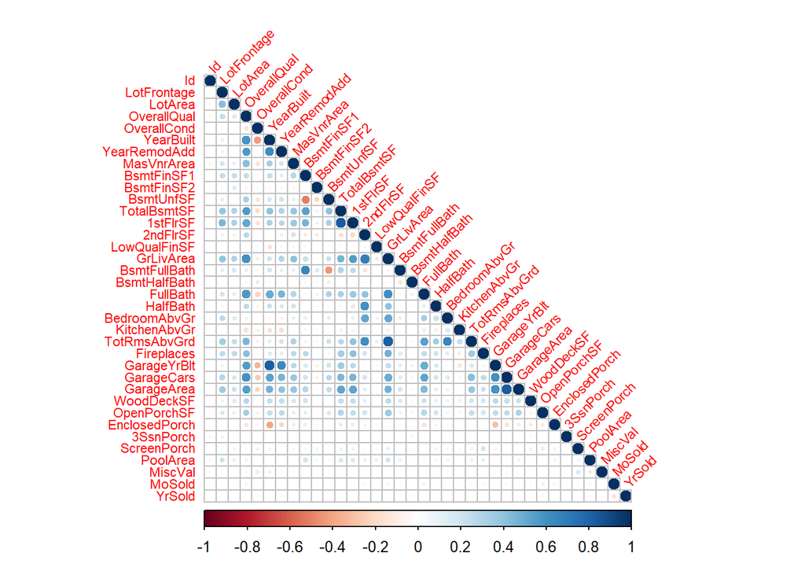

```r
trainCorr %>% corrplot(order = 'original', type = 'lower', tl.srt = 45, tl.cex = 0.7)
```

A few variables have relatively high correlation, but for the most most part the variables are pretty independent.

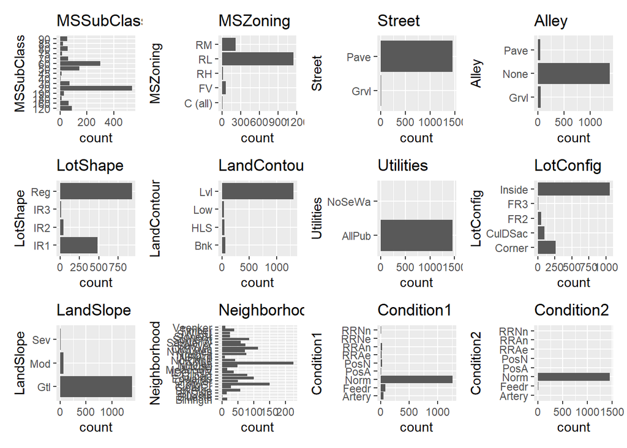

```r
charPlots <- lapply(colnames(select_if(train2, is.character)),
       function(col) {
        ggplot(select_if(train2, is.character),
                aes(.data[[col]])) + geom_bar() +
           coord_flip() + ggtitle(col)
       }
)

charPlots[[1]] + charPlots[[2]] + charPlots[[3]] + charPlots[[4]] + charPlots[[5]] + charPlots[[6]] +
charPlots[[7]] + charPlots[[8]] + charPlots[[9]] + charPlots[[10]] + charPlots[[11]] + charPlots[[12]]
```

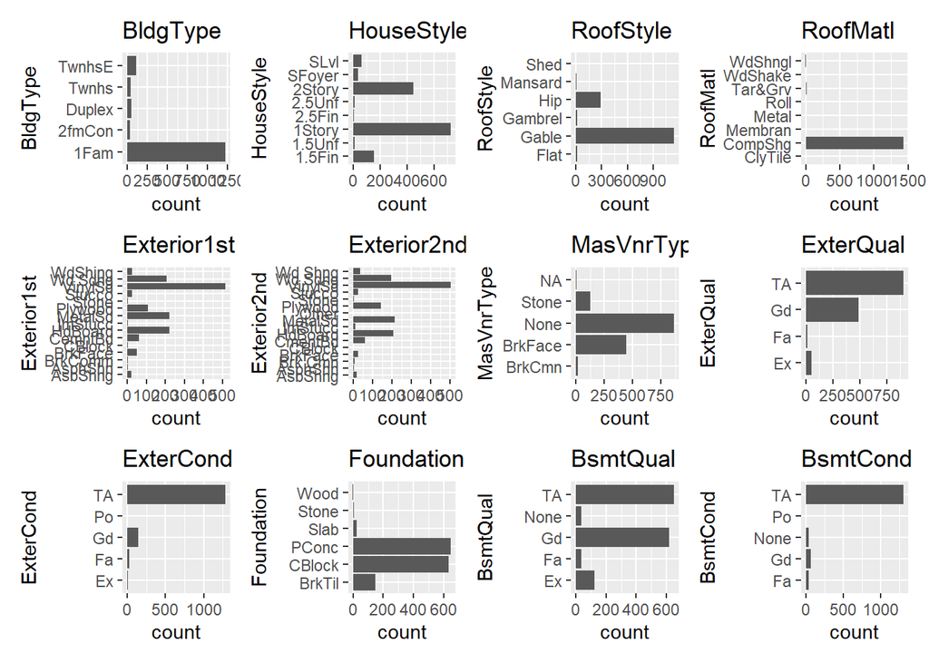

```r
charPlots[[13]] + charPlots[[14]] + charPlots[[15]] + charPlots[[16]] + charPlots[[17]] + charPlots[[18]] +
charPlots[[19]] + charPlots[[20]] + charPlots[[21]] + charPlots[[22]] + charPlots[[23]] + charPlots[[24]]
```

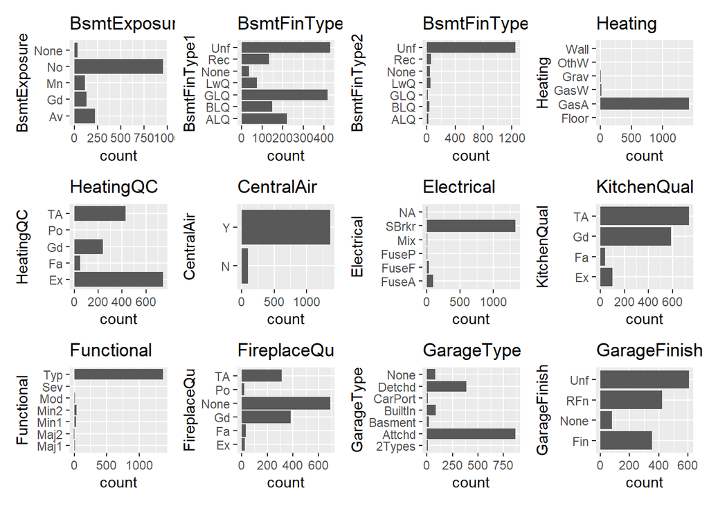

```r
charPlots[[25]] + charPlots[[26]] + charPlots[[27]] + charPlots[[28]] + charPlots[[29]] + charPlots[[30]] +
charPlots[[31]] + charPlots[[32]] + charPlots[[33]] + charPlots[[34]] + charPlots[[35]] + charPlots[[36]]
```

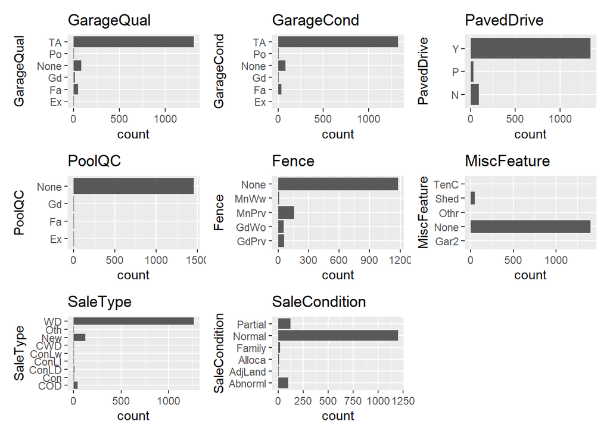

```r
charPlots[[37]] + charPlots[[38]] + charPlots[[39]] + charPlots[[40]] + charPlots[[41]] + charPlots[[42]] +
charPlots[[43]] + charPlots[[44]]
```

```r
names(train2[nearZeroVar(train2)]) %>% as.data.frame()
```

```
##                .
## 1         Street
## 2          Alley
## 3    LandContour
## 4      Utilities
## 5      LandSlope
## 6     Condition2
## 7       RoofMatl
## 8       BsmtCond
## 9   BsmtFinType2
## 10    BsmtFinSF2
## 11       Heating
## 12  LowQualFinSF
## 13  KitchenAbvGr
## 14    Functional
## 15 EnclosedPorch
## 16     3SsnPorch
## 17   ScreenPorch
## 18      PoolArea
## 19        PoolQC
## 20   MiscFeature
## 21       MiscVal
```

We definitely have some variables with Near Zero Variance, so models sensitive to these sorts of variables should have that included in their pre-processing.

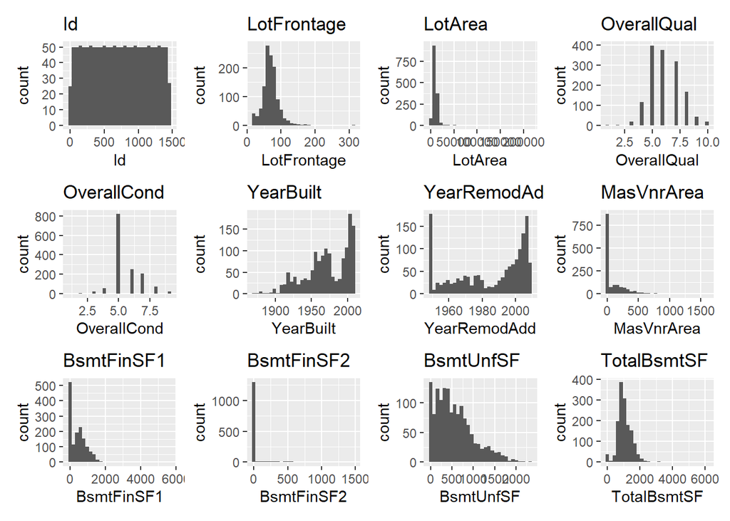

```r
numPlots <- lapply(colnames(select_if(train2, is.numeric)),
       function(col) {
        ggplot(select_if(train2, is.numeric),
                aes(.data[[col]])) + geom_histogram(bins=30) +
           ggtitle(col)
       }
)

numPlots[[1]] + numPlots[[2]] + numPlots[[3]] + numPlots[[4]] + numPlots[[5]] + numPlots[[6]] +
numPlots[[7]] + numPlots[[8]] + numPlots[[9]] + numPlots[[10]] + numPlots[[11]] + numPlots[[12]]
```

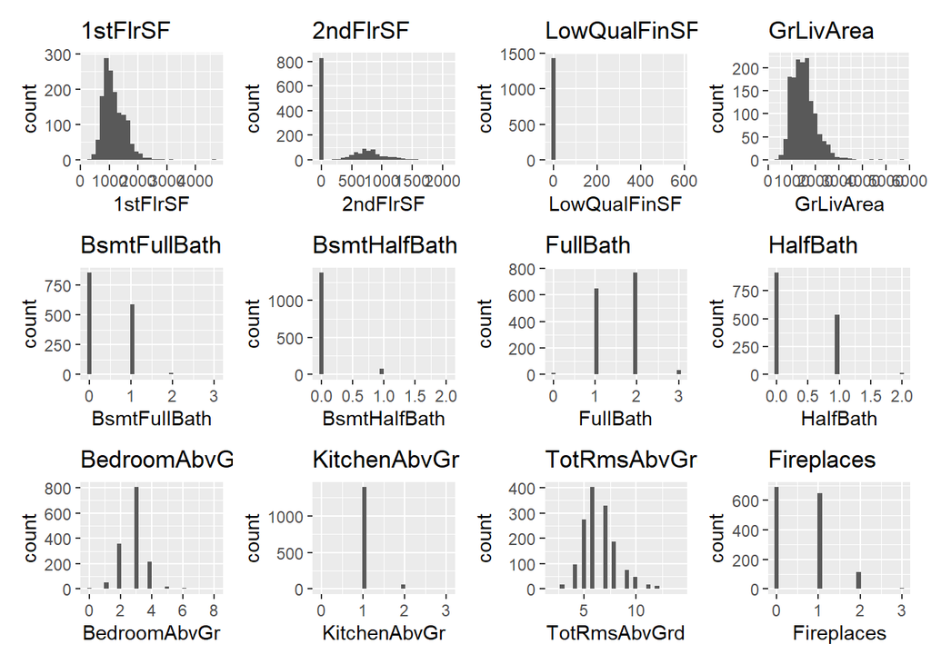

```r
numPlots[[13]] + numPlots[[14]] + numPlots[[15]] + numPlots[[16]] + numPlots[[17]] + numPlots[[18]] +
numPlots[[19]] + numPlots[[20]] + numPlots[[21]] + numPlots[[22]] + numPlots[[23]] + numPlots[[24]]
```

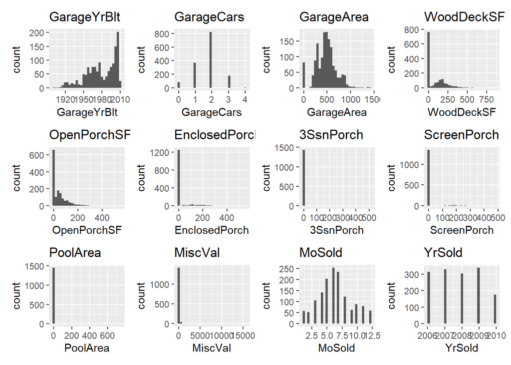

```r
numPlots[[25]] + numPlots[[26]] + numPlots[[27]] + numPlots[[28]] + numPlots[[29]] + numPlots[[30]] +
numPlots[[31]] + numPlots[[32]] + numPlots[[33]] + numPlots[[34]] + numPlots[[35]] + numPlots[[36]]
```

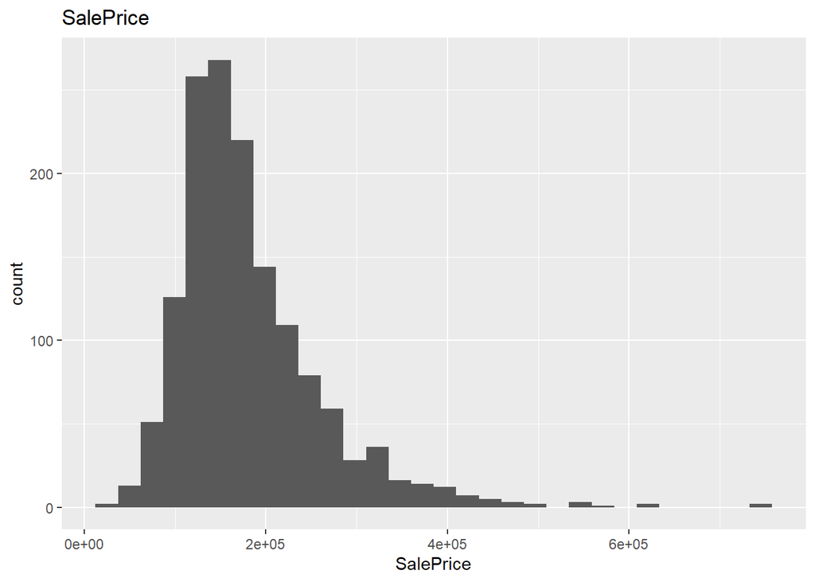

```r
numPlots[[37]]
```

There is definitely some skewness across several of the numeric predictors, so BoxCox transformations will likely be useful for models sensitive to skewness.

Beginning of Model Development—————————————–

The variables that seem reasonable to use moving forward are: OverallQual, GrLivArea, TotalBsmtSF, GarageCars, and FullBath. They don’t appear to have issues with missing values, the appeared highly correlated to Sales Price, and there is only slight skewness (which I will address) among a few of them.

Double checking variance amongst the 5 chosen:

```r
chosen_variables <- c("OverallQual", "GrLivArea", "TotalBsmtSF", "GarageCars", "FullBath")

variances <- sapply(train2[chosen_variables], var, na.rm = TRUE)

print(variances)
```

```
##  OverallQual    GrLivArea  TotalBsmtSF   GarageCars     FullBath
## 1.912679e+00 2.761296e+05 1.924624e+05 5.584797e-01 3.035082e-01
```

```r
skim(chosen_variables)
```

Data summary

| Name | chosen_variables |
| --- | --- |
| Number of rows | 5 |
| Number of columns | 1 |
| _______________________ |  |
| Column type frequency: |  |
| character | 1 |
| ________________________ |  |
| Group variables | None |

**Variable type: character**

| skim_variable | n_missing | complete_rate | min | max | empty | n_unique | whitespace |
| --- | --- | --- | --- | --- | --- | --- | --- |
| data | 0 | 1 | 8 | 11 | 0 | 5 | 0 |

```r
summary(trainRaw %>% select(all_of(chosen_variables)))
```

```
##   OverallQual       GrLivArea     TotalBsmtSF       GarageCars
##  Min.   : 1.000   Min.   : 334   Min.   :   0.0   Min.   :0.000
##  1st Qu.: 5.000   1st Qu.:1130   1st Qu.: 795.8   1st Qu.:1.000
##  Median : 6.000   Median :1464   Median : 991.5   Median :2.000
##  Mean   : 6.099   Mean   :1515   Mean   :1057.4   Mean   :1.767
##  3rd Qu.: 7.000   3rd Qu.:1777   3rd Qu.:1298.2   3rd Qu.:2.000
##  Max.   :10.000   Max.   :5642   Max.   :6110.0   Max.   :4.000
##     FullBath
##  Min.   :0.000
##  1st Qu.:1.000
##  Median :2.000
##  Mean   :1.565
##  3rd Qu.:2.000
##  Max.   :3.000
```

```r
summary(testRaw %>% select(all_of(chosen_variables)))
```

```
##   OverallQual       GrLivArea     TotalBsmtSF     GarageCars       FullBath
##  Min.   : 1.000   Min.   : 407   Min.   :   0   Min.   :0.000   Min.   :0.000
##  1st Qu.: 5.000   1st Qu.:1118   1st Qu.: 784   1st Qu.:1.000   1st Qu.:1.000
##  Median : 6.000   Median :1432   Median : 988   Median :2.000   Median :2.000
##  Mean   : 6.079   Mean   :1486   Mean   :1046   Mean   :1.766   Mean   :1.571
##  3rd Qu.: 7.000   3rd Qu.:1721   3rd Qu.:1305   3rd Qu.:2.000   3rd Qu.:2.000
##  Max.   :10.000   Max.   :5095   Max.   :5095   Max.   :5.000   Max.   :4.000
##                                  NA's   :1      NA's   :1
```

I will need to address the skewness within the GrLivArea and TotalBsmtSF variables before I can move forward with modeling so I will be applying box cox transformation along substituting any NA’s my data for the median value.

```r
box_cox_transform <- function(x) {
  x[is.na(x)] <- median(x, na.rm = TRUE)
  x <- x + 1e-6
  trans <- BoxCoxTrans(x)
  if (trans$lambda == 0) {
    return(log(x))
  } else {
    return(predict(trans, x))
  }
}


train_trans <- trainRaw %>%
  mutate(GrLivArea_BoxCox = box_cox_transform(GrLivArea),
         TotalBsmtSF_BoxCox = box_cox_transform(TotalBsmtSF))

test_trans <- testRaw %>%
  mutate(GrLivArea_BoxCox = box_cox_transform(GrLivArea),
         TotalBsmtSF_BoxCox = box_cox_transform(TotalBsmtSF))
```

Here are the final data sets after transformation:

```r
train_final <- train_trans %>%
  select(SalePrice, OverallQual, GarageCars, FullBath, GrLivArea_BoxCox, TotalBsmtSF_BoxCox)

test_final <- test_trans %>%
  select(OverallQual, GarageCars, FullBath, GrLivArea_BoxCox, TotalBsmtSF_BoxCox)

head(train_final)
```

```
## # A tibble: 6 × 6
##   SalePrice OverallQual GarageCars FullBath GrLivArea_BoxCox TotalBsmtSF_BoxCox
##       <dbl>       <dbl>      <dbl>    <dbl>            <dbl>              <dbl>
## 1    208500           7          2        2             7.44               94.1
## 2    181500           6          2        2             7.14              119.
## 3    223500           7          2        2             7.49               98.4
## 4    140000           7          3        1             7.45               87.2
## 5    250000           8          3        2             7.70              112.
## 6    143000           5          2        1             7.22               90.0
```

```r
head(test_final)
```

```
## # A tibble: 6 × 5
##   OverallQual GarageCars FullBath GrLivArea_BoxCox TotalBsmtSF_BoxCox
##         <dbl>      <dbl>    <dbl>            <dbl>              <dbl>
## 1           5          1        1             6.80               95.9
## 2           6          1        1             7.19              123.
## 3           5          2        2             7.40               98.9
## 4           6          2        2             7.38               98.8
## 5           8          2        2             7.15              120.
## 6           6          2        2             7.41               87.7
```

Next will start the process of implementing a Support Vector Machine model for our data. We’ve chosen this method for predicting housing prices because we’re not entirely sure if relationship between the features and the target is complex or potentially non-linear.

```r
set.seed(100)

x=cbind(predictors, train_final$SalePrice)
inTrain <- createDataPartition(train_final$SalePrice, p=.8)[[1]]
train_data <- train_final[inTrain, ]
test_data <- train_final[-inTrain, ]
```

Implement some centering and scaling…

```r
preProcValues <- preProcess(train_data[, -1], method = c("center", "scale"))
train_data_preprocessed <- predict(preProcValues, train_data[, -1])
test_data_preprocessed <- predict(preProcValues, test_data[, -1])
```

```r
train_data_preprocessed$SalePrice <- train_data$SalePrice
test_data_preprocessed$SalePrice <- test_data$SalePrice
```

Now to train the SVM model…

```r
set.seed(1056)
svmFit <- train(SalePrice ~ .,
                   data = train_data_preprocessed,
                   method = "svmRadial",
                   preProcess = c("center", "scale"),
                   tuneLenght = 10,
                   trControl = trainControl(method = "repeatedcv",
                                            repeats = 10))


print(svmFit)
```

```
## Support Vector Machines with Radial Basis Function Kernel
##
## 1169 samples
##    5 predictor
##
## Pre-processing: centered (5), scaled (5)
## Resampling: Cross-Validated (10 fold, repeated 10 times)
## Summary of sample sizes: 1052, 1052, 1052, 1053, 1051, 1053, ...
## Resampling results across tuning parameters:
##
##   C     RMSE      Rsquared   MAE
##   0.25  39529.95  0.7721956  22831.54
##   0.50  36276.43  0.8054568  21893.41
##   1.00  34022.17  0.8265475  21389.49
##
## Tuning parameter 'sigma' was held constant at a value of 0.2834467
## RMSE was used to select the optimal model using the smallest value.
## The final values used for the model were sigma = 0.2834467 and C = 1.
```

Now to use on the test data and evaluate…

```r
svm_prediction <- predict(svmFit, newdata = test_data_preprocessed)

svm_performance <- postResample(pred = svm_prediction, obs = test_data_preprocessed$SalePrice)
print(svm_performance)
```

```
##         RMSE     Rsquared          MAE
## 30746.717256     0.841221 20888.238215
```

Interpretation of Performance Results for the SVM model:

- The R² value of 0.8412 shows our SVM model explains a substantial portion of the variance in house prices.
- The RMSE and MAE values suggest that the model’s predictions are reasonably close to the actual values but still have room for improvement. The typical prediction error is in the range of $20,000 to $30,000.We could use some additional model tuning or add additional features to improve the prediction accuracy (such as experimenting with some additional hyper parameter tuning)

We’re now going to perform a stepwise linear regression technique know as Multivariate Adaptive Regression Splines or ‘MARS’.

First we will partition the data into training (80%) and testing (20%) sets and then scale and center

```r
set.seed(100)
marsFit <- createDataPartition(train_final$SalePrice, p = 0.8, list = FALSE)
train_data1 <- train_final[marsFit, ]
test_data1 <- train_final[-marsFit, ]


preProcValues1 <- preProcess(train_data1[, -1], method = c("center", "scale"))
train_data_preprocessed1 <- predict(preProcValues1, train_data1[, -1])
test_data_preprocessed1 <- predict(preProcValues1, test_data1[, -1])
test_data_preprocessed1 <- predict(preProcValues1, test_data1[, -1])
```

```r
train_data_preprocessed1$SalePrice <- train_data1$SalePrice
test_data_preprocessed1$SalePrice <- test_data1$SalePrice
```

Now to train the MARS model….

```r
set.seed(100)
ctrl <- trainControl(method = "cv", number = 10)

mars_model <- train(SalePrice ~ ., data = train_data_preprocessed1,
                    method = "earth",
                    tuneGrid = expand.grid(degree = 1, nprune = 2:28),
                    trControl = ctrl)
print(mars_model)
```

```
## Multivariate Adaptive Regression Spline
##
## 1169 samples
##    5 predictor
##
## No pre-processing
## Resampling: Cross-Validated (10 fold)
## Summary of sample sizes: 1050, 1053, 1052, 1052, 1053, 1052, ...
## Resampling results across tuning parameters:
##
##   nprune  RMSE      Rsquared   MAE
##    2      53946.59  0.5456356  41314.52
##    3      42688.24  0.7133175  31481.00
##    4      37196.93  0.7859598  26681.38
##    5      33600.37  0.8237845  24173.98
##    6      33319.07  0.8269721  23595.73
##    7      32308.75  0.8363633  22535.65
##    8      31874.50  0.8411550  22412.85
##    9      32013.97  0.8394907  22501.92
##   10      31772.20  0.8419015  22434.67
##   11      31942.07  0.8403452  22533.59
##   12      31821.16  0.8411630  22449.02
##   13      32012.99  0.8396703  22505.96
##   14      31953.69  0.8401837  22492.57
##   15      31953.69  0.8401837  22492.57
##   16      31953.69  0.8401837  22492.57
##   17      31953.69  0.8401837  22492.57
##   18      31953.69  0.8401837  22492.57
##   19      31953.69  0.8401837  22492.57
##   20      31953.69  0.8401837  22492.57
##   21      31953.69  0.8401837  22492.57
##   22      31953.69  0.8401837  22492.57
##   23      31953.69  0.8401837  22492.57
##   24      31953.69  0.8401837  22492.57
##   25      31953.69  0.8401837  22492.57
##   26      31953.69  0.8401837  22492.57
##   27      31953.69  0.8401837  22492.57
##   28      31953.69  0.8401837  22492.57
##
## Tuning parameter 'degree' was held constant at a value of 1
## RMSE was used to select the optimal model using the smallest value.
## The final values used for the model were nprune = 10 and degree = 1.
```

Now to implement prediction with the test data and evaluate the performance…

```r
mars_predictions <- predict(mars_model, newdata = test_data_preprocessed1)

mars_performance <- postResample(pred = mars_predictions, obs = test_data_preprocessed1$SalePrice)
print(mars_performance)
```

```
##         RMSE     Rsquared          MAE
## 6.780093e+04 4.920042e-01 2.747307e+04
```

Interpretation of Performance Results for the MARS model:

- The R² of 0.4920 means that approximately 49.20% of the variance in house prices is explained by this model
- The RMSE of 67,800.93 indicates that, on average, the predicted house prices differ from the actual prices by approximately $67,800.93. However, the MAE of 27,473.07 indicates that, on average, the absolute errors between the predicted and actual house prices are approximately $27,473.07.

So far, in comparison with the SVM model which had an RMSE of 30,746.72 and an R² of 0.8412, the MARS model is performing worse. The SVM model had lower prediction errors and explained a larger portion of the variance in house prices.

We’re not going to leverage using a Neural Network method for our prediction modeling following the same steps we did in the last two..

```r
set.seed(100)  #
nnetFit <- createDataPartition(train_final$SalePrice, p = 0.8, list = FALSE)
train_data2 <- train_final[nnetFit, ]
test_data2 <- train_final[-nnetFit, ]


preProcValues2 <- preProcess(train_data2[, -1], method = c("center", "scale"))
train_data_preprocessed2 <- predict(preProcValues2, train_data2[, -1])
test_data_preprocessed2 <- predict(preProcValues2, test_data2[, -1])
```

```r
train_data_preprocessed2$SalePrice <- train_data1$SalePrice
test_data_preprocessed2$SalePrice <- test_data1$SalePrice
```

Now to train our Neural Network Model…

```r
set.seed(1056)
ctrl <- trainControl(method = "cv", number = 10)
nnetGrid <- expand.grid(size = c(1, 3), decay = c(0, 0.01, 0.1))

nnet_model <- train(SalePrice ~ ., data = train_data_preprocessed2,
                    method = "nnet",
                    trControl = ctrl,
                    preProc = c("center", "scale"),
                    tuneGrid = nnetGrid,
                    linout = TRUE,
                    trace = FALSE,
                    maxit = 2000,
                    allowParallel = FALSE)
```

```
## Warning in nominalTrainWorkflow(x = x, y = y, wts = weights, info = trainInfo,
## : There were missing values in resampled performance measures.
```

```r
print(nnet_model)
```

```
## Neural Network
##
## 1169 samples
##    5 predictor
##
## Pre-processing: centered (5), scaled (5)
## Resampling: Cross-Validated (10 fold)
## Summary of sample sizes: 1052, 1052, 1052, 1053, 1051, 1053, ...
## Resampling results across tuning parameters:
##
##   size  decay  RMSE      Rsquared   MAE
##   1     0.00   65652.16  0.3631498  45777.44
##   1     0.01   55578.17  0.4774711  38679.03
##   1     0.10   47262.19  0.6776286  32852.88
##   3     0.00   59280.72  0.4220331  39677.51
##   3     0.01   41391.40  0.7233039  27828.59
##   3     0.10   41373.79  0.7228897  28394.41
##
## RMSE was used to select the optimal model using the smallest value.
## The final values used for the model were size = 3 and decay = 0.1.
```

I still received a “Warning: There were missing values in resampled performance measures” even after attempting to simplify my grid, increase my iterations, and using other seed counts

```r
resamples <- nnet_model$resample
summary(resamples)
```

```
##       RMSE          Rsquared           MAE          Resample
##  Min.   :27986   Min.   :0.5184   Min.   :21302   Length:10
##  1st Qu.:31256   1st Qu.:0.6014   1st Qu.:22925   Class :character
##  Median :36703   Median :0.7618   Median :27117   Mode  :character
##  Mean   :41374   Mean   :0.7229   Mean   :28394
##  3rd Qu.:48827   3rd Qu.:0.8183   3rd Qu.:33051
##  Max.   :60804   Max.   :0.8931   Max.   :37351
```

Moving on to reviewing the performance of my NNET model…

```r
nnet_predictions <- predict(nnet_model, newdata = test_data_preprocessed2)


nnet_performance <- postResample(pred = nnet_predictions, obs = test_data_preprocessed2$SalePrice)
print(nnet_performance)
```

```
##         RMSE     Rsquared          MAE
## 4.131419e+04 7.195746e-01 2.955695e+04
```

Interpretation of Performance Results for the NNET model:

- The neural network model’s R² value of 0.7196 indicates that it explains a substantial portion of the variance in house prices
- The RMSE and MAE values suggest that the model’s predictions have a considerable average error. The RMSE of 41,314.19 and MAE of 29,556.95 indicate that the model’s predictions can deviate significantly from the actual house prices.

It appears the SVM model with its RMSE of 30,746.72 and an R² of 0.8412, still shows a better performance in terms of lower prediction errors and higher explanatory power compared to the neural network and the MARS model.

```r
library(grid)
```

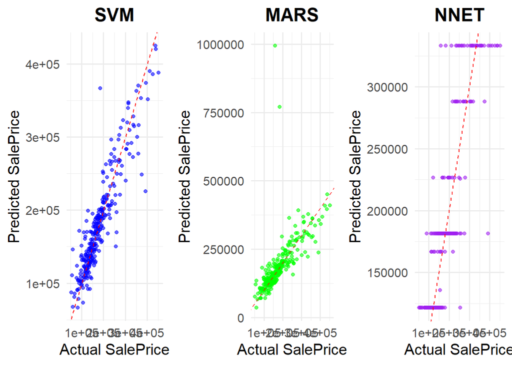

```r
# SVM model plot
svm_plot <- ggplot(data = test_data_preprocessed, aes(x = SalePrice, y = svm_prediction)) +
  geom_point(color = "blue", alpha = 0.6) +
  geom_abline(slope = 1, intercept = 0, color = "red", linetype = "dashed") +
  labs(x = "Actual SalePrice", y = "Predicted SalePrice", title = "SVM") +
  theme_minimal(base_size = 15) +
  theme(plot.title = element_text(hjust = 0.5, face = "bold"))

# MARS model plot
mars_plot <- ggplot(data = test_data_preprocessed1, aes(x = SalePrice, y = mars_predictions)) +
  geom_point(color = "green", alpha = 0.6) +
  geom_abline(slope = 1, intercept = 0, color = "red", linetype = "dashed") +
  labs(x = "Actual SalePrice", y = "Predicted SalePrice", title = "MARS") +
  theme_minimal(base_size = 15) +
  theme(plot.title = element_text(hjust = 0.5, face = "bold"))

# Neural Network model plot
nnet_plot <- ggplot(data = test_data_preprocessed1, aes(x = SalePrice, y = nnet_predictions)) +
  geom_point(color = "purple", alpha = 0.6) +
  geom_abline(slope = 1, intercept = 0, color = "red", linetype = "dashed") +
  labs(x = "Actual SalePrice", y = "Predicted SalePrice", title = "NNET") +
  theme_minimal(base_size = 15) +
  theme(plot.title = element_text(hjust = 0.5, face = "bold"))


# Arrange plots in a grid
grid.newpage()
pushViewport(viewport(layout = grid.layout(1, 3)))

# Function to define layout positions
vplayout <- function(x, y) viewport(layout.pos.row = x, layout.pos.col = y)

# Print the plots in the defined layout
print(svm_plot, vp = vplayout(1, 1))
print(mars_plot, vp = vplayout(1, 2))
print(nnet_plot, vp = vplayout(1, 3))
```